# Problem_Set_3_Markdown

# Problem Set 3

# 1

## a.

A cubic function would overfit the traing data and lead us to reject or accept the null hypothesis incorrctly. Therefore I would say it is safe to assume that a linear model would be preferable than the cubic one as it would not overfit the training data.

## b.

Since the cubic function overfits and the testing data is loaded with errors, you expect to have a lower RSS using linear as opposed to cubic.

# 2.

# a.

There are 14 columns/variables in the data set and there are 506 observations.

```r
library(MASS)
library(corrplot)
help(Boston)
```

# b.

lstat ptratio rm indus

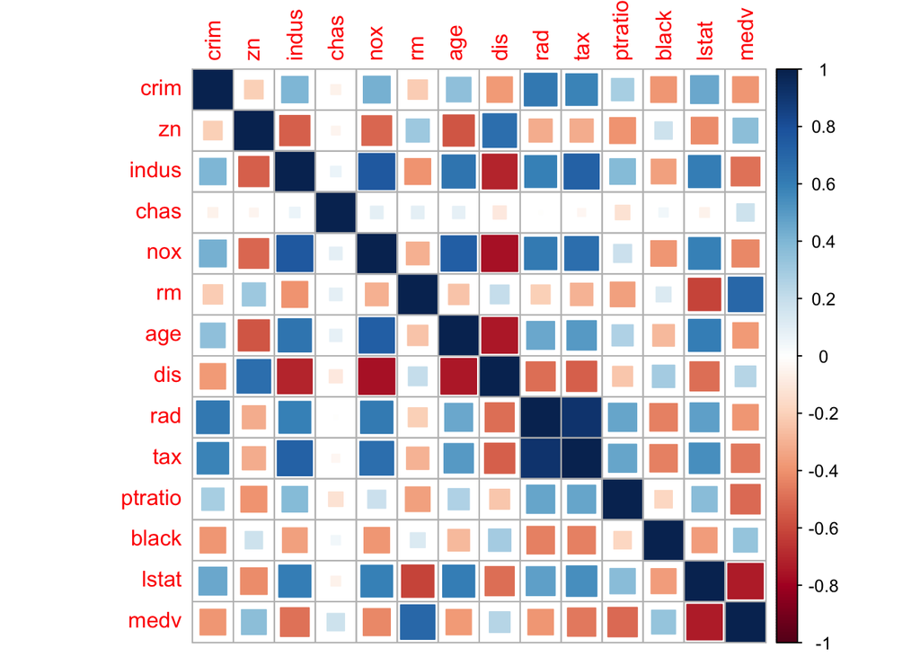

```r
bostonplot <- cor(Boston)
corrplot(bostonplot, method='square')
```

# c.

```r
mod1 <- lm(medv ~ lstat + ptratio + rm + indus, data = Boston)
summary(mod1)
```

```
##
## Call:
## lm(formula = medv ~ lstat + ptratio + rm + indus, data = Boston)
##
## Residuals:
##      Min       1Q   Median       3Q      Max
## -14.5602  -3.1379  -0.7984   1.7783  29.5739
##
## Coefficients:
##              Estimate Std. Error t value Pr(>|t|)
## (Intercept) 18.614970   3.926680   4.741 2.78e-06 ***
## lstat       -0.575711   0.047885 -12.023  < 2e-16 ***
## ptratio     -0.935122   0.120464  -7.763 4.71e-14 ***
## rm           4.515179   0.426286  10.592  < 2e-16 ***
## indus        0.007567   0.043594   0.174    0.862
## ---
## Signif. codes:  0 '***' 0.001 '**' 0.01 '*' 0.05 '.' 0.1 ' ' 1
##
## Residual standard error: 5.234 on 501 degrees of freedom
## Multiple R-squared:  0.6786, Adjusted R-squared:  0.6761
## F-statistic: 264.5 on 4 and 501 DF,  p-value: < 2.2e-16
```

# d.

lstat, ptratio, and rm reject the null hypothesis that median value of owner-occupied homes are not affected by these variables. The only variable that is doesn’t reject the null hypothesis is indus because it has a high P-Value.

# e.

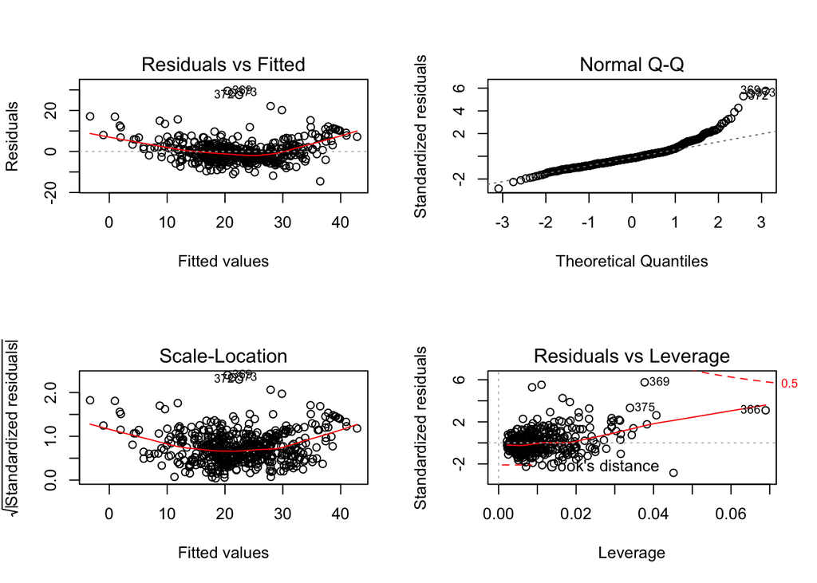

```r
par(mfrow = c(2,2))
plot(mod1)
```

# f.

Yes there is evidence of heteroscadicity on the graphs. There appears to be a U shaped curve on 2 of the Fitted Values graphs.

# g.

```r
loggeddata <- Boston$lnmedv <- log(Boston$medv)
lnmedv <- lm(loggeddata~ lstat + ptratio + rm + indus, data = Boston)
summary(lnmedv)
```

```
##
## Call:
## lm(formula = loggeddata ~ lstat + ptratio + rm + indus, data = Boston)
##
## Residuals:
##      Min       1Q   Median       3Q      Max
## -0.92790 -0.11001 -0.01274  0.10998  0.86993
##
## Coefficients:
##              Estimate Std. Error t value Pr(>|t|)
## (Intercept)  3.535070   0.164366  21.507  < 2e-16 ***
## lstat       -0.034376   0.002004 -17.150  < 2e-16 ***
## ptratio     -0.037987   0.005042  -7.533 2.33e-13 ***
## rm           0.104442   0.017844   5.853 8.73e-09 ***
## indus       -0.001878   0.001825  -1.029    0.304
## ---
## Signif. codes:  0 '***' 0.001 '**' 0.01 '*' 0.05 '.' 0.1 ' ' 1
##
## Residual standard error: 0.2191 on 501 degrees of freedom
## Multiple R-squared:  0.7149, Adjusted R-squared:  0.7127
## F-statistic: 314.1 on 4 and 501 DF,  p-value: < 2.2e-16
```

# h.

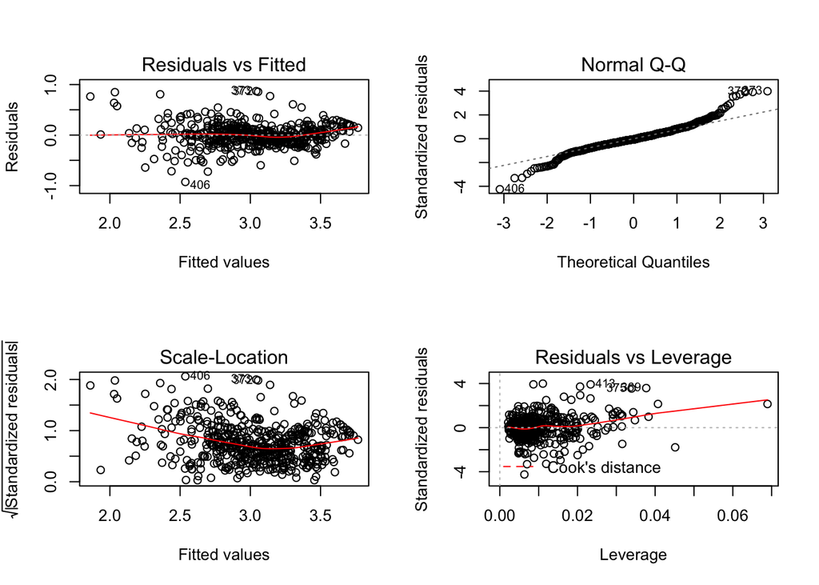

```r
par(mfrow = c(2,2))
plot(lnmedv)
```

Yes there is still some heteroscdastity still prevalent in the data. It has been slighly reduced but there still evidence of it in the Scale-Location graph

# i.

```r
rmSq <-Boston$rmSq <- Boston$rm * Boston$rm
medgraph <- lm(lnmedv~ rm + rmSq + ptratio, data = Boston)
summary(medgraph)
```

```
##
## Call:
## lm(formula = lnmedv ~ rm + rmSq + ptratio, data = Boston)
##
## Residuals:
##     Min      1Q  Median      3Q     Max
## -1.1430 -0.1217  0.0590  0.1714  1.3125
##
## Coefficients:
##              Estimate Std. Error t value Pr(>|t|)
## (Intercept)  3.855021   0.576644   6.685 6.15e-11 ***
## rm          -0.222718   0.176997  -1.258  0.20886
## rmSq         0.041036   0.013753   2.984  0.00299 **
## ptratio     -0.057533   0.006447  -8.924  < 2e-16 ***
## ---
## Signif. codes:  0 '***' 0.001 '**' 0.01 '*' 0.05 '.' 0.1 ' ' 1
##
## Residual standard error: 0.291 on 502 degrees of freedom
## Multiple R-squared:  0.4962, Adjusted R-squared:  0.4932
## F-statistic: 164.8 on 3 and 502 DF,  p-value: < 2.2e-16
```

# j

```r
rmData <- data.frame(rm = 1:7, rmSq = 1:7 * 1:7, ptratio = rep(18.57,7))
summary(rmData)
```

```
##        rm           rmSq         ptratio
##  Min.   :1.0   Min.   : 1.0   Min.   :18.57
##  1st Qu.:2.5   1st Qu.: 6.5   1st Qu.:18.57
##  Median :4.0   Median :16.0   Median :18.57
##  Mean   :4.0   Mean   :20.0   Mean   :18.57
##  3rd Qu.:5.5   3rd Qu.:30.5   3rd Qu.:18.57
##  Max.   :7.0   Max.   :49.0   Max.   :18.57
```

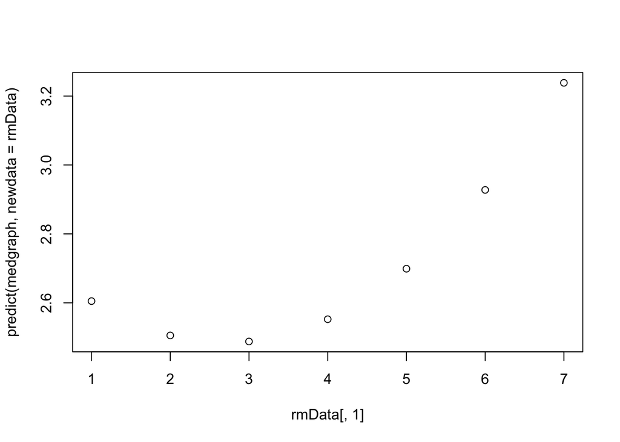

```r
plot(rmData[, 1], predict(medgraph, newdata = rmData))
```

# 3

```r
set.seed(1861)
x1 <- runif(100)
x2 <- 2 + x1 + rnorm(100, 0, 0.02)
Y <- 1 * x1 + 1 * x2 + rnorm(100)
DF <- data.frame(Y, x1, x2)
```

# a.

The data, x1 and x2, appear to have a linear relationship.

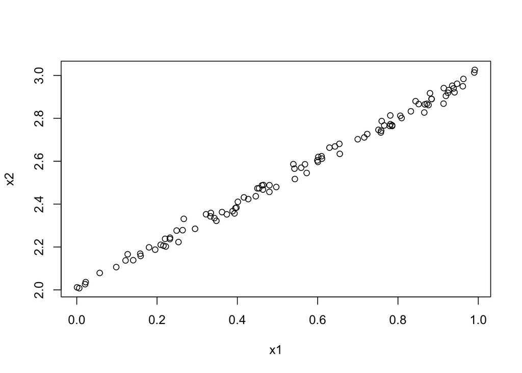

```r
plot(x1,x2)
```

# b.

Yes X1 and X2 are very correlated. They have an r value of .99.

```r
cor(x1,x2)
```

```
## [1] 0.9975058
```

# c.

```r
mod2 <- lm(Y~x1 + x2, data = DF)
summary(mod2)
```

```
##
## Call:
## lm(formula = Y ~ x1 + x2, data = DF)
##
## Residuals:
##      Min       1Q   Median       3Q      Max
## -2.58089 -0.66373 -0.02267  0.62852  2.25911
##
## Coefficients:
##             Estimate Std. Error t value Pr(>|t|)
## (Intercept)    6.010      9.411   0.639    0.525
## x1             4.323      4.669   0.926    0.357
## x2            -2.114      4.687  -0.451    0.653
##
## Residual standard error: 0.9344 on 97 degrees of freedom
## Multiple R-squared:  0.3202, Adjusted R-squared:  0.3062
## F-statistic: 22.84 on 2 and 97 DF,  p-value: 7.422e-09
```

x1 = 4.323 x2 = -2.114

# d.

The value of the coefficients should be 1 as indiciated on the Y equation. Y <- 1 * x1 + 1 * x2 + rnorm(100). 1 is the clear coefficient of x1and x2

# e.

```r
mod3 <- lm(Y~x1, data =  DF)
summary(mod3)
```

```
##
## Call:
## lm(formula = Y ~ x1, data = DF)
##
## Residuals:
##      Min       1Q   Median       3Q      Max
## -2.67131 -0.62930 -0.04688  0.57545  2.33560
##
## Coefficients:
##             Estimate Std. Error t value Pr(>|t|)
## (Intercept)   1.7672     0.2022   8.742 6.47e-14 ***
## x1            2.2224     0.3282   6.772 9.46e-10 ***
## ---
## Signif. codes:  0 '***' 0.001 '**' 0.01 '*' 0.05 '.' 0.1 ' ' 1
##
## Residual standard error: 0.9306 on 98 degrees of freedom
## Multiple R-squared:  0.3188, Adjusted R-squared:  0.3118
## F-statistic: 45.86 on 1 and 98 DF,  p-value: 9.46e-10
```

## x1 = 2.22

```r
mod4 <- lm(Y~x2, data = DF)
summary(mod4)
```

```
##
## Call:
## lm(formula = Y ~ x2, data = DF)
##
## Residuals:
##      Min       1Q   Median       3Q      Max
## -2.76623 -0.61195 -0.04742  0.58785  2.40945
##
## Coefficients:
##             Estimate Std. Error t value Pr(>|t|)
## (Intercept)  -2.6677     0.8484  -3.144   0.0022 **
## x2            2.2150     0.3306   6.701 1.32e-09 ***
## ---
## Signif. codes:  0 '***' 0.001 '**' 0.01 '*' 0.05 '.' 0.1 ' ' 1
##
## Residual standard error: 0.9338 on 98 degrees of freedom
## Multiple R-squared:  0.3142, Adjusted R-squared:  0.3072
## F-statistic:  44.9 on 1 and 98 DF,  p-value: 1.323e-09
```

## x2 = 2.215

# f.

X1 plotted against Y has has a higher R^2 and a lower a P value therefore X1 is my preferred data. There isn’t a significant differece in the data as both have very similar R^2 I would prefer the one with a higher R value and the lowest P value.